# LBB Unsupervised Learning

Francis Yeh

8 Apr 2020

# 1 Introduction

## 1.1 Background

Imagine you are employed at a particular conglomerate distributing FMCG goods through a distribution network consisting of hotel, restaurant, cafes and all variety of retail outlets. Our CRM system collected the annual spending in each of the product category for each of the customer grouping ie,Horeca and Retail and we would like to apply Unsupervised Learning algorithms, namely

1. Dimensionality Reduction (using PCA)
2. Clustering (using k-means clustering)

to potentially help the conglomerate in their customer segmentation (beyond the existing customer grouping(channel) and region), sales group assignment and/or campaign execution.

## 1.2 Data Source

The dataset consists of 440 observations and 8 variables. https://archive.ics.uci.edu/ml/datasets/Wholesale+customers

### 1.2.1 Overview of Variables

1. CHANNEL: customer classification
   - 1 = Horeca (Hotel/Restaurant/Cafe) or
   - 2 = Retail
2. REGION: customers Region (1 = Lisnon, 2 = Oporto or 3 = Others)
3. FRESH: annual spending (m.u) on fresh products (Continuous);
4. MILK: annual spending (m.u) on milk products (Continuous);
5. GROCERY: annual spending (m.u)on grocery products (Continuous);
6. FROZEN: annual spending (m.u)on frozen products (Continuous)
7. DETERGENTS_PAPER: annual spending (m.u) on detergents and paper products (Continuous)
8. DELICATESSEN: annual spending (m.u)on and delicatessen products (Continuous);

## 1.3 Libraries and Setup

### 1.3.1 Within Sum of Squares

```r
wss <- function(data, maxCluster = 9) {
    # Initialize within sum of squares
    SSw <- (nrow(data) - 1) * sum(apply(data, 2, var))
    SSw <- vector()
    for (i in 2:maxCluster) {
        SSw[i] <- sum(kmeans(data, centers = i)$withinss)
    }
    plot(1:maxCluster, SSw, type = "o", xlab = "Number of Clusters", ylab = "Within groups sum of squares", pch=19)
}
```

# 2 Preprocessing

## 2.1 Data Table

```r
wholesale <- read.csv("data_input/wholesale.csv", header=TRUE)

str(wholesale)
```

```
## 'data.frame':    440 obs. of  8 variables:
##  $ Channel         : int  2 2 2 1 2 2 2 2 1 2 ...
##  $ Region          : int  3 3 3 3 3 3 3 3 3 3 ...
##  $ Fresh           : int  12669 7057 6353 13265 22615 9413 12126 7579 5963 6006 ...
##  $ Milk            : int  9656 9810 8808 1196 5410 8259 3199 4956 3648 11093 ...
##  $ Grocery         : int  7561 9568 7684 4221 7198 5126 6975 9426 6192 18881 ...
##  $ Frozen          : int  214 1762 2405 6404 3915 666 480 1669 425 1159 ...
##  $ Detergents_Paper: int  2674 3293 3516 507 1777 1795 3140 3321 1716 7425 ...
##  $ Delicassen      : int  1338 1776 7844 1788 5185 1451 545 2566 750 2098 ...
```

## 2.2 Checking missing values

```r
describe(wholesale)
```

```
## wholesale
##
##  8  Variables      440  Observations
## --------------------------------------------------------------------------------
## Channel
##        n  missing distinct     Info     Mean      Gmd
##      440        0        2    0.656    1.323   0.4381
##
## Value          1     2
## Frequency    298   142
## Proportion 0.677 0.323
## --------------------------------------------------------------------------------
## Region
##        n  missing distinct     Info     Mean      Gmd
##      440        0        3    0.623    2.543   0.6951
##
## Value          1     2     3
## Frequency     77    47   316
## Proportion 0.175 0.107 0.718
## --------------------------------------------------------------------------------
## Fresh
##        n  missing distinct     Info     Mean      Gmd      .05      .10
##      440        0      433        1    12000    12256    401.9    915.6
##      .25      .50      .75      .90      .95
##   3127.8   8504.0  16933.8  27090.5  36818.5
##
## lowest :      3      9     18     23     37, highest:  56083  56159  68951  76237 112151
## --------------------------------------------------------------------------------
## Milk
##        n  missing distinct     Info     Mean      Gmd      .05      .10
##      440        0      421        1     5796     6152    593.8    889.8
##      .25      .50      .75      .90      .95
##   1533.0   3627.0   7190.2  12229.9  16843.4
##
## lowest :    55   112   134   201   254, highest: 38369 43950 46197 54259 73498
## --------------------------------------------------------------------------------
## Grocery
##        n  missing distinct     Info     Mean      Gmd      .05      .10
##      440        0      430        1     7951     8365    851.5   1381.9
##      .25      .50      .75      .90      .95
```

[output cut: 23 more lines]

```
##      .25      .50      .75      .90      .95
##   408.25   965.50  1820.25  2945.90  4485.40
##
## lowest :     3     7     8    11    18, highest:  8550 14351 14472 16523 47943
##
## Value          0   500  1000  1500  2000  2500  3000  3500  4000  4500  5000
## Frequency     65   121    82    54    42    23    18     8     1     5     8
## Proportion 0.148 0.275 0.186 0.123 0.095 0.052 0.041 0.018 0.002 0.011 0.018
##
## Value       5500  6000  6500  7000  8000  8500 14500 16500 48000
## Frequency      1     3     2     1     1     1     2     1     1
## Proportion 0.002 0.007 0.005 0.002 0.002 0.002 0.005 0.002 0.002
##
## For the frequency table, variable is rounded to the nearest 500
## --------------------------------------------------------------------------------
```

# 3 Exploratory Data Analysis

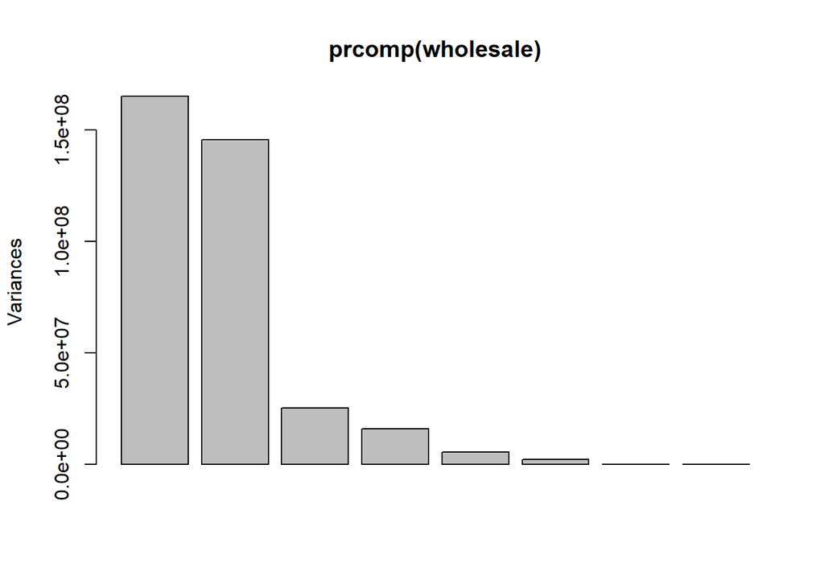

```r
wholesale.pca <- prcomp(wholesale, scale=TRUE)

plot(prcomp(wholesale))
```

## 3.1 Loadings

Loadings are the correlations between the original predictor variables and the principal components. It identifies which of the original variables are driving the principal components.

```r
loadings <- wholesale.pca$rotation
loadings
```

```
##                          PC1         PC2           PC3         PC4         PC5
## Channel          -0.42829156  0.20469886  0.0829798863 -0.02964416  0.03620585
## Region           -0.02472603 -0.04312964  0.9825008891 -0.07784462 -0.13250892
## Fresh             0.02531946 -0.51344468  0.0889509074  0.79847592  0.25811686
## Milk             -0.47440995 -0.20554061 -0.0257510842 -0.05402202  0.07208576
## Grocery          -0.53632914  0.00871762 -0.0453143572  0.12158624 -0.11172990
## Frozen            0.02997456 -0.59274525 -0.1221565222 -0.16131688 -0.75421244
## Detergents_Paper -0.52390630  0.12108309 -0.0474814388  0.15101211 -0.17650264
## Delicassen       -0.16499653 -0.53318082  0.0009301994 -0.53755767  0.54482721
##                          PC6          PC7          PC8
## Channel          -0.86350670  0.139899044  0.019335373
## Region            0.08976479 -0.023279938 -0.001545045
## Fresh            -0.14747474 -0.027173693 -0.033851114
## Milk              0.31593256  0.789020414 -0.039291347
## Grocery           0.21369889 -0.353064294  0.715984124
## Frozen           -0.19435993 -0.005336793 -0.012983225
## Detergents_Paper  0.19575356 -0.371374310 -0.691672189
## Delicassen       -0.05453289 -0.306582655 -0.075642587
```

Component 1 is negatively related to Grocery, Detergents_Paper, Milk and Channel and Component 2 is negatively related to Frozen, Delicassen and Fresh. Region does not provide the variability in Component 1 and 2. We can therefore remove Region.

## 3.2 Relationship Across Predictors

```r
cov(scale(wholesale[,c(3:8)]))
```

```
##                        Fresh      Milk     Grocery      Frozen Detergents_Paper
## Fresh             1.00000000 0.1005098 -0.01185387  0.34588146       -0.1019529
## Milk              0.10050977 1.0000000  0.72833512  0.12399376        0.6618157
## Grocery          -0.01185387 0.7283351  1.00000000 -0.04019274        0.9246407
## Frozen            0.34588146 0.1239938 -0.04019274  1.00000000       -0.1315249
## Detergents_Paper -0.10195294 0.6618157  0.92464069 -0.13152491        1.0000000
## Delicassen        0.24468997 0.4063683  0.20549651  0.39094747        0.0692913
##                  Delicassen
## Fresh             0.2446900
## Milk              0.4063683
## Grocery           0.2054965
## Frozen            0.3909475
## Detergents_Paper  0.0692913
## Delicassen        1.0000000
```

There is somewhat high correlation between Detergents_paper, Grocery and Milk. There is some correlation between Fresh, Frozen and Delicassen.

```r
summary(wholesale.pca)
```

```
## Importance of components:
##                           PC1    PC2    PC3    PC4     PC5     PC6     PC7
## Standard deviation     1.7607 1.3379 1.0059 0.8593 0.74608 0.67772 0.53021
## Proportion of Variance 0.3875 0.2238 0.1265 0.0923 0.06958 0.05741 0.03514
## Cumulative Proportion  0.3875 0.6112 0.7377 0.8300 0.89960 0.95701 0.99215
##                            PC8
## Standard deviation     0.25058
## Proportion of Variance 0.00785
## Cumulative Proportion  1.00000
```

Component 1 contributes to 38.75% of the variance followed by 22.38% for Component 2.In order to explain 80% or greater of the variation, we will need 4 components(PC).

Let remove Channel, Region field and perform the analysis

```r
wholesale1 <- wholesale[ ,c(3:8)]  ## exclude Channel, Region
```

```r
library(FactoMineR)
wholesale1.pca <- PCA(wholesale1, scale.unit=TRUE, graph=FALSE)
summary(wholesale1.pca)
```

```
##
## Call:
## PCA(X = wholesale1, scale.unit = TRUE, graph = FALSE)
##
##
## Eigenvalues
##                        Dim.1   Dim.2   Dim.3   Dim.4   Dim.5   Dim.6
## Variance               2.645   1.703   0.740   0.564   0.286   0.063
## % of var.             44.083  28.376  12.334   9.396   4.761   1.050
## Cumulative % of var.  44.083  72.459  84.794  94.189  98.950 100.000
##
## Individuals (the 10 first)
##                      Dist    Dim.1    ctr   cos2    Dim.2    ctr   cos2
## 1                |  0.795 |  0.193  0.003  0.059 | -0.305  0.012  0.147 |
## 2                |  0.753 |  0.434  0.016  0.333 | -0.328  0.014  0.190 |
## 3                |  2.332 |  0.811  0.057  0.121 |  0.815  0.089  0.122 |
## 4                |  1.133 | -0.779  0.052  0.472 |  0.653  0.057  0.332 |
## 5                |  1.577 |  0.166  0.002  0.011 |  1.271  0.216  0.650 |
## 6                |  0.736 | -0.156  0.002  0.045 | -0.295  0.012  0.161 |
## 7                |  0.738 | -0.335  0.010  0.206 | -0.525  0.037  0.506 |
## 8                |  0.623 |  0.141  0.002  0.051 | -0.231  0.007  0.137 |
## 9                |  0.884 | -0.517  0.023  0.343 | -0.659  0.058  0.557 |
## 10               |  1.782 |  1.592  0.218  0.799 | -0.741  0.073  0.173 |
##                   Dim.3    ctr   cos2
## 1                 0.141  0.006  0.031 |
## 2                -0.319  0.031  0.179 |
## 3                -1.523  0.713  0.427 |
## 4                -0.163  0.008  0.021 |
## 5                -0.066  0.001  0.002 |
## 6                -0.148  0.007  0.040 |
## 7                 0.303  0.028  0.169 |
## 8                -0.390  0.047  0.392 |
## 9                -0.183  0.010  0.043 |
## 10               -0.210  0.014  0.014 |
##
## Variables
##                     Dim.1    ctr   cos2    Dim.2    ctr   cos2    Dim.3    ctr
## Fresh            |  0.070  0.184  0.005 |  0.689 27.871  0.475 |  0.699 65.976
## Milk             |  0.887 29.715  0.786 |  0.109  0.692  0.012 | -0.052  0.365
## Grocery          |  0.942 33.554  0.887 | -0.191  2.134  0.036 |  0.093  1.175
## Frozen           |  0.083  0.262  0.007 |  0.798 37.366  0.636 | -0.153  3.182
## Detergents_Paper |  0.892 30.101  0.796 | -0.333  6.514  0.111 |  0.117  1.855
## Delicassen       |  0.404  6.184  0.164 |  0.658 25.422  0.433 | -0.451 27.448
##                    cos2
## Fresh             0.488 |
## Milk              0.003 |
## Grocery           0.009 |
## Frozen            0.024 |
## Detergents_Paper  0.014 |
## Delicassen        0.203 |
```

Interestingly, using FactoMineR package,one can get a much more detailed output when performing the PCA. Dimension/Component 1 contributes to 44.08% of the variance followed by 28.38% for Dimension / Component 2.In order to explain 80% or greater of the variation, the first 3 components(PC) will be sufficient to explain the variances.

We can see that the Dim. 1, Dim. 2, and Dim. 3 have very little correlation.

# 4 Plot PCA

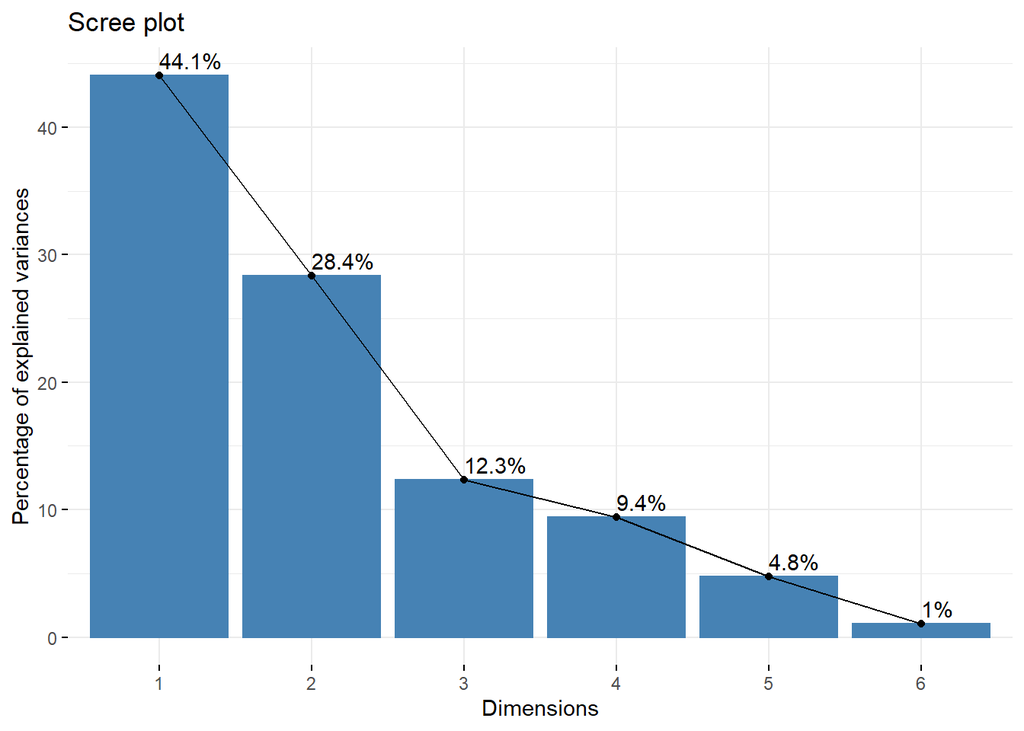

```r
library(factoextra)
fviz_eig(wholesale1.pca, addlabels = TRUE)
```

The Scree Plot provides a visual representation how the no of Principal Components influence the percentage of explained variances.

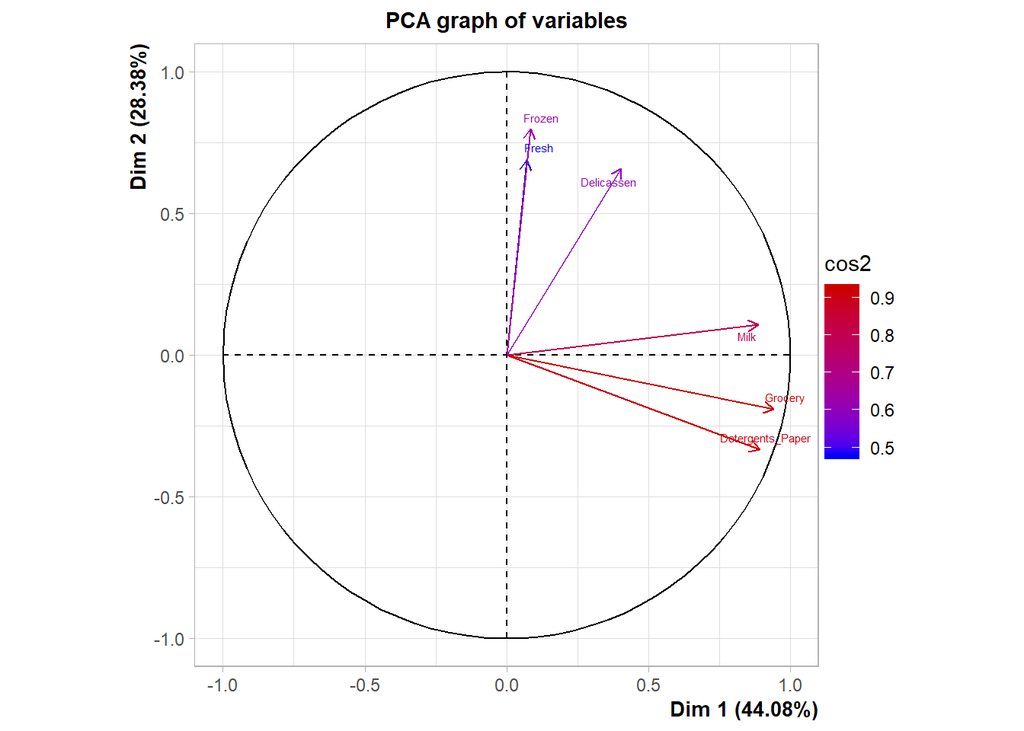

```r
plot.PCA(wholesale1.pca,
         cex=0.5,
         choix = "var",
         select="contrib 6",
         habillage="cos2")
```

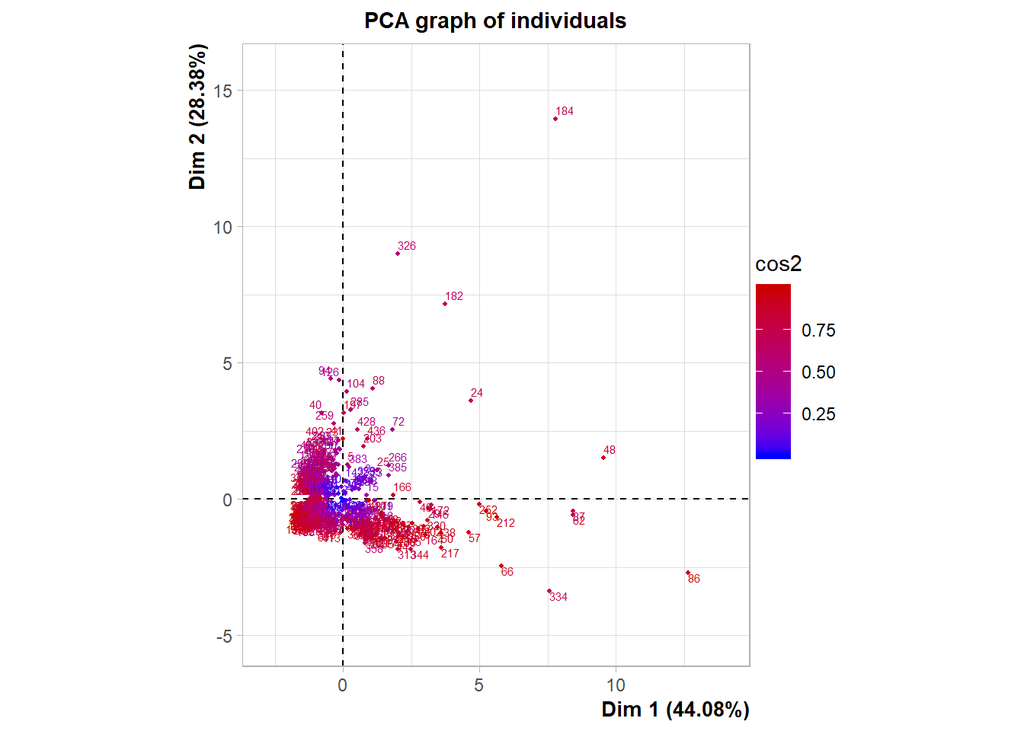

```r
plot.PCA(wholesale1.pca,
         cex=0.5,
         choix = "ind",
         select=1:440,
         habillage="cos2")
```

# 5 k-means Clustering

Here, we decide to start with k= 3 since we have existing “Channel” variable in our data which comprises 2 “clusters” ie. Horeca and Retail.

```r
set.seed = 10
library(factoextra)
wholesalekm_res <- kmeans(wholesale1, centers = 3, nstart = 25)
```

The output of Kmeans returns a list of components. The most important one are listed below:

cluster: A vector of integers (from 1:k) indicating the cluster to which each point is allocated.

centers: A matrix of cluster centers.

totss: The total sum of squares.

withinss: Vector of within-cluster sum of squares, one component per cluster. tot.withinss: Total within-cluster sum of squares, i.e. sum(withinss).

betweenss: The between-cluster sum of squares, i.e. $totss-tot.withinss$. size: The number of points in each cluster.

## 5.1 Within Sum of Squares

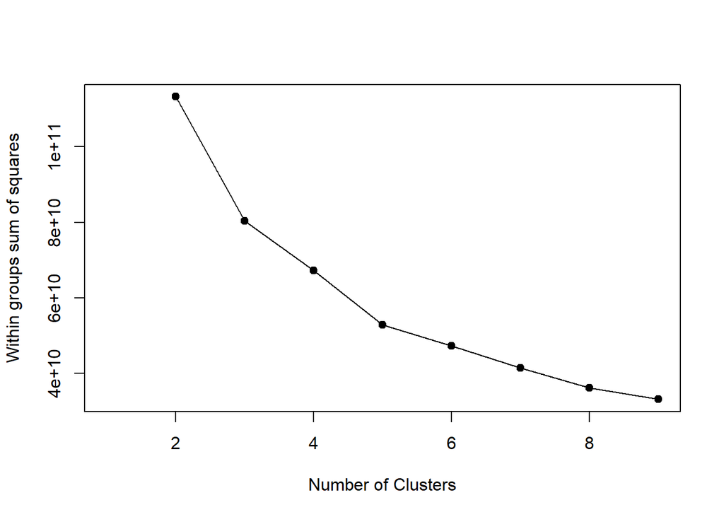

```r
wss(wholesale1)
```

## 5.2 Adding cluster classification to the original data

```r
wholesalekm_df <- cbind(wholesale1,channel=wholesale$Channel, cluster=wholesalekm_res$cluster)
head(wholesalekm_df)
```

```
##   Fresh Milk Grocery Frozen Detergents_Paper Delicassen channel cluster
## 1 12669 9656    7561    214             2674       1338       2       1
## 2  7057 9810    9568   1762             3293       1776       2       1
## 3  6353 8808    7684   2405             3516       7844       2       1
## 4 13265 1196    4221   6404              507       1788       1       1
## 5 22615 5410    7198   3915             1777       5185       2       3
## 6  9413 8259    5126    666             1795       1451       2       1
```

```r
# write.csv(wholesalekm_df, "wholesalekmdf.csv")
```

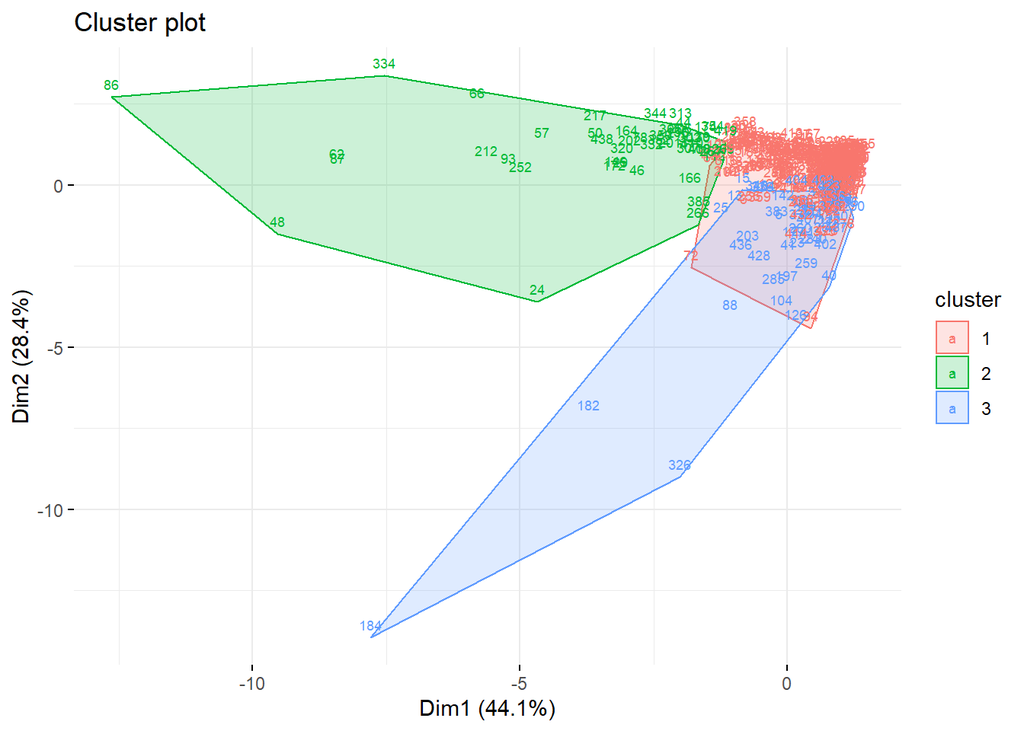

```r
# Show text only
fviz_cluster(wholesalekm_res,wholesale1,repel = FALSE,show.clust.cent = TRUE,labelsize = 7, ggtheme = theme_minimal(),geom = "text")
```

```r
table(wholesalekm_df$channel, wholesalekm_df$cluster)
```

```
##
##       1   2   3
##   1 244   2  52
##   2  86  48   8
```

# 6 Summary

After breaking down the clusters to 3, let see how the business may benefit from the clustering. We can generalise the clusters as below:

Cluster 2 (size 50) - Relatively higher proportion of purchase (in term of DM) in Grocery, Milk, Detergents_Paper categories (as compared to Frozen, Fresh, Delicassen) from mostly the Retail channel

Application: Business could decide if the above clustering could be used in scenarios such as target group selection for campaign execution.

Further iterations of the clustering maybe necessary if business requires clear segregation in term of Horeca and Retail or decide the no of clusters potentially needed based on some optimal cluster size.